## Income Level Prediction - Data Science Capstone Project

## 🎯 Project Overview

This capstone project aims to build a machine learning model that predicts whether an individual's income exceeds $50,000 per year based on census data. By analyzing demographic and employment-related features, the goal is to gain insights into income distribution and to create a predictive tool that can support socio-economic research and policy planning.

The project follows a structured machine learning pipeline that includes:

- **Data Collection and Inspection**
- **Exploratory Data Analysis (EDA)**
- **Data Preprocessing and Feature Engineering**
- **Model Selection, Training, and Evaluation**
- **Insights and Recommendations**

## 🗓️ Timeline

**Duration**: 3 Weeks  
**Start Date**: June 1st  
**End Date**: June 20th

## 📦 Dataset

The dataset is derived from U.S. Census Bureau data and includes features such as age, education, work class, marital status, occupation, and capital gain/loss. The target variable is **income**, categorized as `<=50K` or `>50K`.

## 🧰 Tools & Technologies

- Python
- Pandas, NumPy
- Matplotlib, Seaborn
- Scikit-learn
- Jupyter Notebook

## 🏁 Objective

To develop an accurate and interpretable machine learning model that predicts whether a person earns more than $50,000/year, and to extract actionable insights from the data.

### Step 1: Import Required Libraries

### Step 2: Load and Inspect Dataset

```
First 5 Rows:
```

|  | age | workclass | fnlwgt | education | education-num | marital-status | occupation | relationship | race | sex | capital-gain | capital-loss | hours-per-week | native-country | income |
| --- | --- | --- | --- | --- | --- | --- | --- | --- | --- | --- | --- | --- | --- | --- | --- |
| 0 | 39 | State-gov | 77516 | Bachelors | 13 | Never-married | Adm-clerical | Not-in-family | White | Male | 2174 | 0 | 40 | United-States | <=50K |
| 1 | 50 | Self-emp-not-inc | 83311 | Bachelors | 13 | Married-civ-spouse | Exec-managerial | Husband | White | Male | 0 | 0 | 13 | United-States | <=50K |
| 2 | 38 | Private | 215646 | HS-grad | 9 | Divorced | Handlers-cleaners | Not-in-family | White | Male | 0 | 0 | 40 | United-States | <=50K |
| 3 | 53 | Private | 234721 | 11th | 7 | Married-civ-spouse | Handlers-cleaners | Husband | Black | Male | 0 | 0 | 40 | United-States | <=50K |
| 4 | 28 | Private | 338409 | Bachelors | 13 | Married-civ-spouse | Prof-specialty | Wife | Black | Female | 0 | 0 | 40 | Cuba | <=50K |

### Step 3: Data Cleaning & Preparation

```
 Data Info:
<class 'pandas.core.frame.DataFrame'>
RangeIndex: 48842 entries, 0 to 48841
Data columns (total 15 columns):
 #   Column          Non-Null Count  Dtype
---  ------          --------------  -----
 0   age             48842 non-null  int64
 1   workclass       47879 non-null  object
 2   fnlwgt          48842 non-null  int64
 3   education       48842 non-null  object
 4   education-num   48842 non-null  int64
 5   marital-status  48842 non-null  object
 6   occupation      47876 non-null  object
 7   relationship    48842 non-null  object
 8   race            48842 non-null  object
 9   sex             48842 non-null  object
 10  capital-gain    48842 non-null  int64
 11  capital-loss    48842 non-null  int64
 12  hours-per-week  48842 non-null  int64
 13  native-country  48568 non-null  object
 14  income          48842 non-null  object
dtypes: int64(6), object(9)
memory usage: 5.6+ MB
None

 Summary Statistics:
```

|  | age | fnlwgt | education-num | capital-gain | capital-loss | hours-per-week |
| --- | --- | --- | --- | --- | --- | --- |
| count | 48842.000000 | 4.884200e+04 | 48842.000000 | 48842.000000 | 48842.000000 | 48842.000000 |
| mean | 38.643585 | 1.896641e+05 | 10.078089 | 1079.067626 | 87.502314 | 40.422382 |
| std | 13.710510 | 1.056040e+05 | 2.570973 | 7452.019058 | 403.004552 | 12.391444 |
| min | 17.000000 | 1.228500e+04 | 1.000000 | 0.000000 | 0.000000 | 1.000000 |
| 25% | 28.000000 | 1.175505e+05 | 9.000000 | 0.000000 | 0.000000 | 40.000000 |
| 50% | 37.000000 | 1.781445e+05 | 10.000000 | 0.000000 | 0.000000 | 40.000000 |
| 75% | 48.000000 | 2.376420e+05 | 12.000000 | 0.000000 | 0.000000 | 45.000000 |
| max | 90.000000 | 1.490400e+06 | 16.000000 | 99999.000000 | 4356.000000 | 99.000000 |

```
 Missing Values Before:
age                 0
workclass         963
education           0
education-num       0
marital-status      0
occupation        966
relationship        0
race                0
sex                 0
capital-gain        0
capital-loss        0
hours-per-week      0
native-country    274
income              0
dtype: int64

 Missing Values After:
age               0
workclass         0
education         0
education-num     0
marital-status    0
occupation        0
relationship      0
race              0
sex               0
capital-gain      0
capital-loss      0
hours-per-week    0
native-country    0
income            0
dtype: int64
```

### Step 4: Exploratory Data Analysis (EDA)

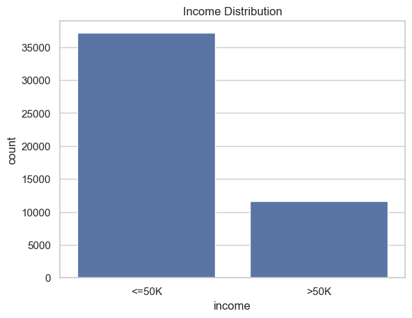

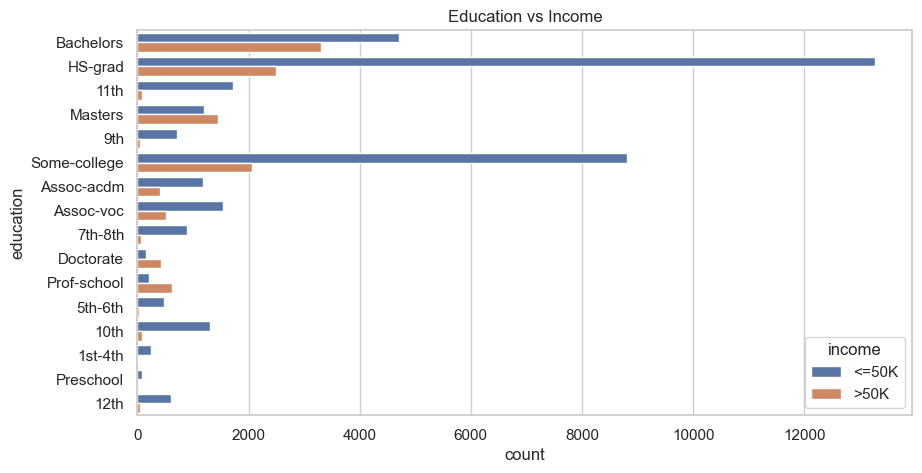

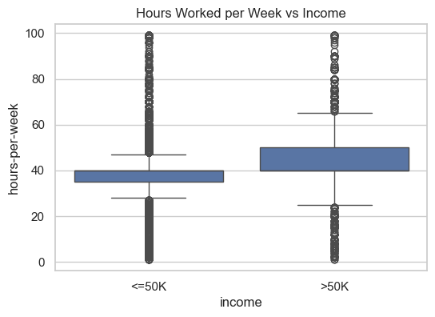

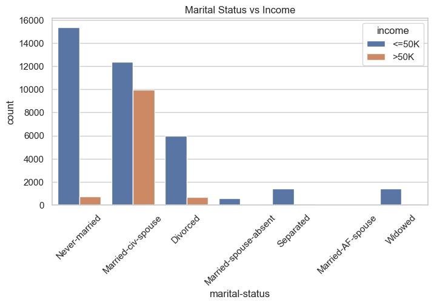

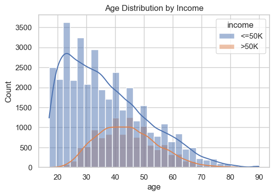

### Step 5: Feature Engineering & Preprocessing

```
Missing Values:
 Series([], dtype: int64)

Missing values after imputation:
 0
Original feature shape: (48842, 100)
Reduced feature shape after PCA: (48842, 31)
```

### Step 6: Model Training and Evaluation

```
📊 Evaluation Metrics Summary
```

|  | Model | Accuracy | Precision | Recall | F1 Score | ROC AUC |
| --- | --- | --- | --- | --- | --- | --- |
| 0 | Gradient Boosting | 0.862524 | 0.768484 | 0.609068 | 0.679551 | 0.911459 |
| 1 | Logistic Regression | 0.848500 | 0.730150 | 0.582121 | 0.647787 | 0.902506 |
| 2 | SVM | 0.856997 | 0.769011 | 0.575278 | 0.658184 | 0.887937 |
| 3 | Random Forest | 0.845634 | 0.704232 | 0.612062 | 0.654920 | 0.884148 |
| 4 | KNN | 0.839390 | 0.686560 | 0.605218 | 0.643328 | 0.861722 |

#### Confusion Matrix for Best Model ( Gradient Boosting)

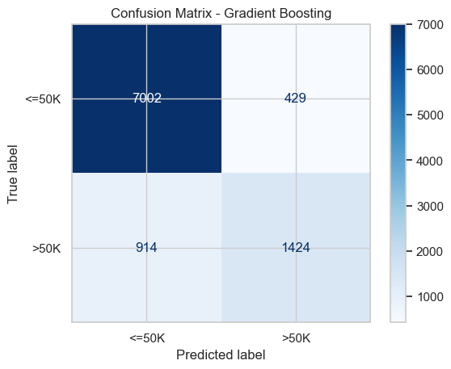

### Step 7: ROC Curve Comparison

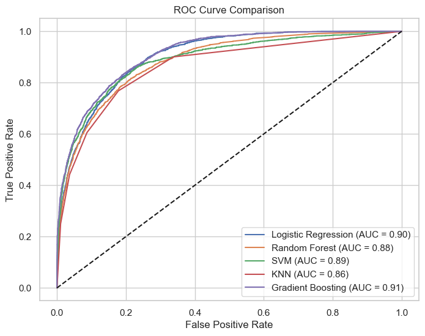

### Step 8: Save the Best Model

```
Model saved as income_prediction_model.pkl
```

### ✅ Recommendations

1. **Gradient Boosting** is recommended for deployment due to its strong and consistent performance.
2. For further optimization:
   - Apply **hyperparameter tuning** (e.g., using GridSearchCV or RandomizedSearchCV).
   - Explore **ensemble strategies** like stacking or blending multiple models.
   - Analyze **feature importances** to interpret key drivers of income.
3. Deploy the best-performing model using a REST API (e.g., Flask or FastAPI).
4. Continuously **monitor model performance** for signs of data drift or degradation.
5. Consider gathering **updated or more diverse data** to enhance generalization and robustness across populations.

✅ **Project Completed Successfully**